# Data Cleaning and kNN Imputation for Forest Cover Dataset

Nazgul Altynbekova

```r
# Add any other packages you need to load here.
library(tidyverse)
library(skimr)
library(visdat)
library(naniar)
library(VIM)
library(Manu)
library(mice)

# Read in the data
cover <- read_csv("cover.csv")
cover_types <- read_csv("cover_types.csv")
attach(cover)
```

### 1

#### Checking data for missing values

```r
head(cover)
```

```
## # A tibble: 6 × 10
##   Elevation Slope H.dist V.dist D.Road Shade9 Shade12 Shade3 D.Fire  Type
##       <dbl> <dbl>  <dbl>  <dbl>  <dbl>  <dbl>   <dbl>  <dbl>  <dbl> <dbl>
## 1      2281    21     30     11   1101    161     241    217    306     3
## 2      2742    14    192     43   3692    216     251    167   1913     2
## 3      3309    17    577     85   3047    200     203    136   3465     1
## 4      2993     9    566     72   1944    201     226    165    900     1
## 5      2849    11    391     53   2640    240     230    118   1702     2
## 6      3264    16     85     10   1154    230     245    141   1116     1
```

```r
cover
```

```
## # A tibble: 8,000 × 10
##    Elevation Slope H.dist V.dist D.Road Shade9 Shade12 Shade3 D.Fire  Type
##        <dbl> <dbl>  <dbl>  <dbl>  <dbl>  <dbl>   <dbl>  <dbl>  <dbl> <dbl>
##  1      2281    21     30     11   1101    161     241    217    306     3
##  2      2742    14    192     43   3692    216     251    167   1913     2
##  3      3309    17    577     85   3047    200     203    136   3465     1
##  4      2993     9    566     72   1944    201     226    165    900     1
##  5      2849    11    391     53   2640    240     230    118   1702     2
##  6      3264    16     85     10   1154    230     245    141   1116     1
##  7      3000    13    301     57   1740    185     226    180   2424     2
##  8      3131     9    175     22   2100    215     221    143    853     1
##  9      3314    21    162     26   2297    176     199    159   2218     2
## 10      3063    10    467     83    589    196     229    173    607     2
## # ℹ 7,990 more rows
```

```r
#-9999
cover |> skim()
```

Data summary

| Name | cover |
| --- | --- |
| Number of rows | 8000 |
| Number of columns | 10 |
| _______________________ |  |
| Column type frequency: |  |
| numeric | 10 |
| ________________________ |  |
| Group variables | None |

**Variable type: numeric**

| skim_variable | n_missing | complete_rate | mean | sd | p0 | p25 | p50 | p75 | p100 | hist |
| --- | --- | --- | --- | --- | --- | --- | --- | --- | --- | --- |
| Elevation | 0 | 1 | 2958.34 | 280.94 | 1892 | 2801 | 2996.0 | 3164.0 | 3781 | ▁▂▇▇▁ |
| Slope | 0 | 1 | 14.05 | 7.47 | 0 | 9 | 13.0 | 18.0 | 50 | ▆▇▃▁▁ |
| H.dist | 0 | 1 | 272.82 | 242.20 | -9999 | 108 | 228.0 | 391.0 | 1382 | ▁▁▁▁▇ |
| V.dist | 0 | 1 | 33.10 | 376.75 | -9999 | 7 | 30.0 | 70.0 | 568 | ▁▁▁▁▇ |
| D.Road | 0 | 1 | 2341.12 | 1558.50 | 0 | 1103 | 1985.0 | 3306.5 | 6974 | ▇▇▅▂▁ |
| Shade9 | 0 | 1 | 212.16 | 26.87 | 54 | 198 | 218.0 | 231.0 | 254 | ▁▁▁▅▇ |
| Shade12 | 0 | 1 | 223.33 | 19.63 | 99 | 213 | 226.0 | 237.0 | 254 | ▁▁▁▅▇ |
| Shade3 | 0 | 1 | 15.88 | 1127.47 | -9999 | 118 | 143.0 | 168.0 | 249 | ▁▁▁▁▇ |
| D.Fire | 0 | 1 | 1973.68 | 1332.53 | 0 | 1019 | 1704.5 | 2526.0 | 6932 | ▇▇▂▁▁ |
| Type | 0 | 1 | 2.07 | 1.40 | 1 | 1 | 2.0 | 2.0 | 7 | ▇▁▁▁▁ |

```r
#H.dist, V.dist, Shade3
```

“-9999” is used to encode missing values.

Now we’re looking for variables H.dist, V.dist, Shade3 to count missing values:

```r
cover |>
  summarise(miss_H.dist = sum(H.dist == -9999),
            miss_V.dist = sum(V.dist == -9999),
            miss_Shade3 = sum(Shade3 == -9999))
```

```
## # A tibble: 1 × 3
##   miss_H.dist miss_V.dist miss_Shade3
##         <int>       <int>       <int>
## 1           1          11         100
```

Counting rows that contain more than one missing value:

```r
sum(rowSums(cover == -9999, na.rm = TRUE) > 1)
```

```
## [1] 0
```

Seems like there’s no rows with more than one missing value at a time

#### Cleaning missing values by replacing with NA

```r
cover_na <- cover |>
  replace_with_na_all(
    condition = ~.x == -9999)

skim(cover_na)
```

Data summary

| Name | cover_na |
| --- | --- |
| Number of rows | 8000 |
| Number of columns | 10 |
| _______________________ |  |
| Column type frequency: |  |
| numeric | 10 |
| ________________________ |  |
| Group variables | None |

**Variable type: numeric**

| skim_variable | n_missing | complete_rate | mean | sd | p0 | p25 | p50 | p75 | p100 | hist |
| --- | --- | --- | --- | --- | --- | --- | --- | --- | --- | --- |
| Elevation | 0 | 1.00 | 2958.34 | 280.94 | 1892 | 2801 | 2996.0 | 3164.0 | 3781 | ▁▂▇▇▁ |
| Slope | 0 | 1.00 | 14.05 | 7.47 | 0 | 9 | 13.0 | 18.0 | 50 | ▆▇▃▁▁ |
| H.dist | 1 | 1.00 | 274.11 | 213.25 | 0 | 108 | 228.0 | 391.0 | 1382 | ▇▅▁▁▁ |
| V.dist | 11 | 1.00 | 46.91 | 57.93 | -117 | 7 | 30.0 | 70.0 | 568 | ▆▇▁▁▁ |
| D.Road | 0 | 1.00 | 2341.12 | 1558.50 | 0 | 1103 | 1985.0 | 3306.5 | 6974 | ▇▇▅▂▁ |
| Shade9 | 0 | 1.00 | 212.16 | 26.87 | 54 | 198 | 218.0 | 231.0 | 254 | ▁▁▁▅▇ |
| Shade12 | 0 | 1.00 | 223.33 | 19.63 | 99 | 213 | 226.0 | 237.0 | 254 | ▁▁▁▅▇ |
| Shade3 | 100 | 0.99 | 142.65 | 38.11 | 0 | 119 | 143.0 | 168.0 | 249 | ▁▂▇▆▁ |
| D.Fire | 0 | 1.00 | 1973.68 | 1332.53 | 0 | 1019 | 1704.5 | 2526.0 | 6932 | ▇▇▂▁▁ |
| Type | 0 | 1.00 | 2.07 | 1.40 | 1 | 1 | 2.0 | 2.0 | 7 | ▇▁▁▁▁ |

```r
attach(cover_na)
```

#### Plotting `H.dist` vs `Type`

```r
class(Type)
```

```
## [1] "numeric"
```

```r
Type = as.factor(Type)
cover_types
```

```
## # A tibble: 7 × 2
##    Type Description
##   <dbl> <chr>
## 1     1 Spruce-Fir
## 2     2 Lodgepole Pine
## 3     3 Ponderosa Pine
## 4     4 Cottonwood/Willow
## 5     5 Aspen
## 6     6 Douglas-fir
## 7     7 Krummholz
```

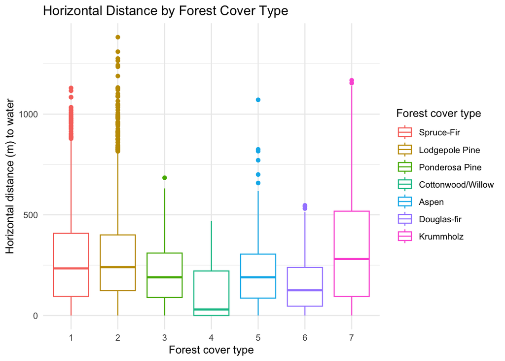

```r
cover_na |>
  ggplot() +
  geom_boxplot(mapping = aes(
    x = factor(Type),
    y = H.dist,
    color = factor(Type))) +
  labs(x = "Forest cover type",
       y = "Horizontal distance (m) to water",
       title = "Horizontal Distance by Forest Cover Type") +
  scale_color_discrete(name = "Forest cover type",
                       labels = c("Spruce-Fir", "Lodgepole Pine", "Ponderosa Pine","Cottonwood/Willow",
                                "Aspen", "Douglas-fir", "Krummholz")) +
  theme_minimal()
```

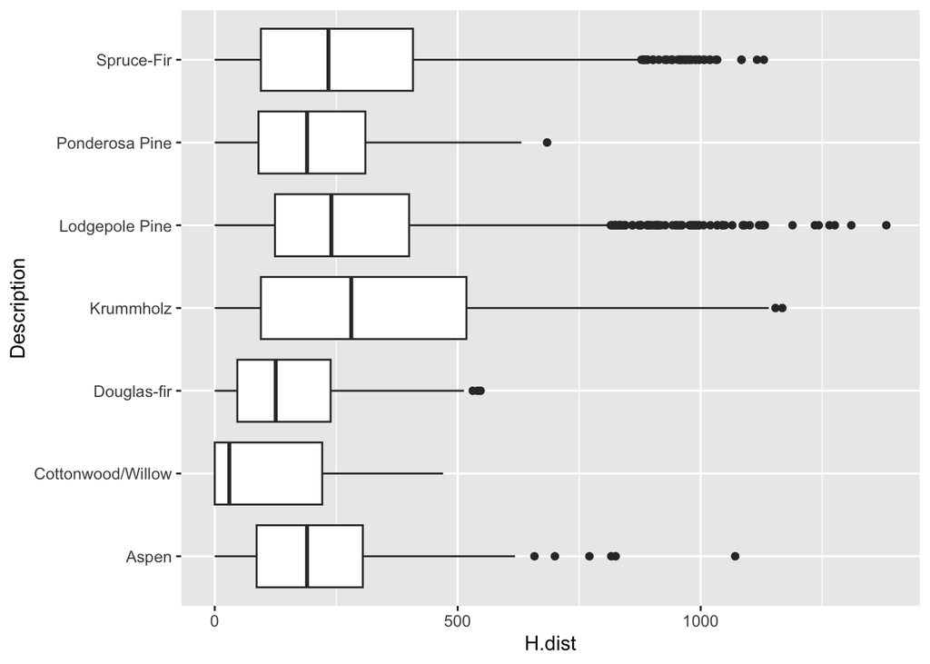

```r
cover_na |> left_join(cover_types) |>
  ggplot() +
  geom_boxplot(mapping = aes(y = Description, x = H.dist))
```

#### Applying kNN imputation

```r
#I want to find which row has a missing value of H.dist to identify its Type
na_row <- which(is.na(cover_na$H.dist))
cover_na[1096, ]
```

```
## # A tibble: 1 × 10
##   Elevation Slope H.dist V.dist D.Road Shade9 Shade12 Shade3 D.Fire  Type
##       <dbl> <dbl>  <dbl>  <dbl>  <dbl>  <dbl>   <dbl>  <dbl>  <dbl> <dbl>
## 1      3114    11     NA     70   1634    213     217    139    531     2
```

```r
cover_na_Type2 <- cover_na |>
  filter(Type == 2)

#Now I created a table with all the imputed values of H.dist in Type 2 using a for loop
kays <- c(1, 2, 5, 10, 20, 50, 100, 500, 1000, 5000)
imp_H.dist <- vector("list", length(kays))

for (a in kays) {
  new_df <- kNN(cover_na_Type2, variable = "H.dist", k = a)
  imp_H.dist[[as.character(a)]] <- new_df$H.dist[na_row]
}

imp_table <- data.frame(k = kays, imp_H.dist_value = unlist(imp_H.dist))
imp_table
```

```
##         k imp_H.dist_value
## 1       1               67
## 2       2               67
## 5       5               67
## 10     10               67
## 20     20               67
## 50     50               67
## 100   100               67
## 500   500               67
## 1000 1000               67
## 5000 5000               67
```

Filtering only Type 2 data created the same imputed values of H.dist, no matter the value of k, which indicates that using Type as a predictor for H.dist probably reduces the dataset too much, so that knn imputation becomes insufficient.

```r
#I wanted to check if imputation shos better result using the whole dataset
kays <- c(1, 2, 5, 10, 20, 50, 100, 500, 1000, 5000)
imp_H.dist2 <- vector("list", length(kays))

for (a in kays) {
  new_df2 <- kNN(cover_na, variable = "H.dist", k = a)
  imp_H.dist2[[as.character(a)]] <- new_df2$H.dist[na_row]
}

imp_table2 <- data.frame(k = kays, imp_H.dist_value_full = unlist(imp_H.dist2))
imp_table2
```

```
##         k imp_H.dist_value_full
## 1       1                 124.0
## 2       2                 183.0
## 5       5                 255.0
## 10     10                 266.0
## 20     20                 270.0
## 50     50                 273.5
## 100   100                 286.0
## 500   500                 270.0
## 1000 1000                 242.0
## 5000 5000                 234.0
```

It did! Relying on Type variable wasn’t the best idea, and k-nearest neighbour imputation produced clearer results with the full dataset.

```r
k_values <- tibble(k = c(1,2,5,10,20,50,100,500,1000,5000))

# helper function to do the kNN for a given k
my_kNN <- function(k) {
  kNN(cover_na |> mutate(Type = as_factor(Type)),
      variable="H.dist",
      k = k)
}

imputed_h_dist <- k_values |>
  mutate(knn = map(k, my_kNN)) |>
  unnest(knn) |>
  filter(H.dist_imp)

imputed_h_dist
```

```
## # A tibble: 10 × 12
##        k Elevation Slope H.dist V.dist D.Road Shade9 Shade12 Shade3 D.Fire Type
##    <dbl>     <dbl> <dbl>  <dbl>  <dbl>  <dbl>  <dbl>   <dbl>  <dbl>  <dbl> <fct>
##  1     1      3114    11   124      70   1634    213     217    139    531 2
##  2     2      3114    11   183      70   1634    213     217    139    531 2
##  3     5      3114    11   255      70   1634    213     217    139    531 2
##  4    10      3114    11   262.     70   1634    213     217    139    531 2
##  5    20      3114    11   262.     70   1634    213     217    139    531 2
##  6    50      3114    11   277      70   1634    213     217    139    531 2
##  7   100      3114    11   286      70   1634    213     217    139    531 2
##  8   500      3114    11   255      70   1634    213     217    139    531 2
##  9  1000      3114    11   255      70   1634    213     217    139    531 2
## 10  5000      3114    11   234      70   1634    213     217    139    531 2
## # ℹ 1 more variable: H.dist_imp <lgl>
```

#### Table of imputed values

```r
imputed_h_dist |>
  select(k, H.dist)
```

```
## # A tibble: 10 × 2
##        k H.dist
##    <dbl>  <dbl>
##  1     1   124
##  2     2   183
##  3     5   255
##  4    10   262.
##  5    20   262.
##  6    50   277
##  7   100   286
##  8   500   255
##  9  1000   255
## 10  5000   234
```

```r
  #knitr::kable()
```

The imputed values for the different k showed an interesting dinamic in H.dist values’ changes. For k up to 10 imputed values increase rather dramatically, nearly doubling its value by the k = 10. After that increasing pace slowed down and by the point of k = 100 got to its peak. Then, interestingly, with larger values of k, imputed values started to decrease.

As known, the larger number of k brings more stable value of imputed variable. However, as we see in the Table, the same effect could be accomplished with k = 4 or 5.

### 2

```r
# re-read the data
cover <- read_csv("cover.csv")
```

#### Table of lowest and highest elevation by type

```r
cover |>
  mutate(forest_name = recode(Type,
                             "1" = "Spruce-Fir",
                             "2" = "Lodgepole Pine",
                             "3" = "Ponderosa Pine",
                             "4" = "Cottonwood/Willow",
                             "5" = "Aspen",
                             "6" = "Douglas-fir",
                             "7" = "Krummholz")) |>
  group_by(forest_name) |>
  summarise(lowest_elevation = min(Elevation),
            highest_elevation = max(Elevation))
```

```
## # A tibble: 7 × 3
##   forest_name       lowest_elevation highest_elevation
##   <chr>                        <dbl>             <dbl>
## 1 Aspen                         2494              2969
## 2 Cottonwood/Willow             2000              2481
## 3 Douglas-fir                   1892              2856
## 4 Krummholz                     2889              3781
## 5 Lodgepole Pine                2147              3408
## 6 Ponderosa Pine                1929              2887
## 7 Spruce-Fir                    2523              3659
```

```r
cover |>
  group_by(Type) |>
  summarise(Lowest = min(Elevation), Highest = max(Elevation)) |>
  left_join(cover_types) |>
  select(`Forest Type` = Description, Lowest, Highest)
```

```
## # A tibble: 7 × 3
##   `Forest Type`     Lowest Highest
##   <chr>              <dbl>   <dbl>
## 1 Spruce-Fir          2523    3659
## 2 Lodgepole Pine      2147    3408
## 3 Ponderosa Pine      1929    2887
## 4 Cottonwood/Willow   2000    2481
## 5 Aspen               2494    2969
## 6 Douglas-fir         1892    2856
## 7 Krummholz           2889    3781
```

```r
  #knitr::kable()
```

#### Table of slopes by type corresponding to lowest and highest elevation

Table that shows at which Slopes do the lowest and highest elevations occur for each of these forest types.

Finding the rows corresponding to the lowest and highest elevations for each forest type, and then using the Slope variable in the table.

```r
cover |>
  mutate(forest_name = recode(Type,
                             "1" = "Spruce-Fir",
                             "2" = "Lodgepole Pine",
                             "3" = "Ponderosa Pine",
                             "4" = "Cottonwood/Willow",
                             "5" = "Aspen",
                             "6" = "Douglas-fir",
                             "7" = "Krummholz"))  |>
  group_by(forest_name)  |>
  summarise(lowest = min(Elevation),
            highest = max(Elevation),
            lowest_slope = Slope[which.min(Elevation)],
            highest_slope = Slope[which.max(Elevation)]) |>

  pivot_longer(cols = c(lowest, highest),
               names_to = "elevation_type",
               values_to = "elevation_value")  |>
  mutate(slope = ifelse(elevation_type == "lowest", lowest_slope, highest_slope))  |>
  select(forest_name, elevation_type, elevation_value, slope)
```

```
## # A tibble: 14 × 4
##    forest_name       elevation_type elevation_value slope
##    <chr>             <chr>                    <dbl> <dbl>
##  1 Aspen             lowest                    2494     0
##  2 Aspen             highest                   2969    14
##  3 Cottonwood/Willow lowest                    2000     7
##  4 Cottonwood/Willow highest                   2481     8
##  5 Douglas-fir       lowest                    1892    30
##  6 Douglas-fir       highest                   2856    15
##  7 Krummholz         lowest                    2889    30
##  8 Krummholz         highest                   3781    18
##  9 Lodgepole Pine    lowest                    2147    13
## 10 Lodgepole Pine    highest                   3408    15
## 11 Ponderosa Pine    lowest                    1929     1
## 12 Ponderosa Pine    highest                   2887    23
## 13 Spruce-Fir        lowest                    2523    11
## 14 Spruce-Fir        highest                   3659    13
```

```r
lowest <- cover |>
  group_by(Type) |>
  slice_min(Elevation) |>
  select(Type, Lowest = Slope)

highest <- cover |>
  group_by(Type) |>
  slice_max(Elevation) |>
  select(Type, Highest = Slope)

lowest |> left_join(highest) |>
  left_join(cover_types) |>
  ungroup() |>
  select(`Forest Type` = Description, `Slope at Lowest Elevation` = Lowest, `Slope at Highest Elevation` = Highest)
```

```
## # A tibble: 7 × 3
##   `Forest Type`     `Slope at Lowest Elevation` `Slope at Highest Elevation`
##   <chr>                                   <dbl>                        <dbl>
## 1 Spruce-Fir                                 11                           13
## 2 Lodgepole Pine                             13                           15
## 3 Ponderosa Pine                              1                           23
## 4 Cottonwood/Willow                           7                            8
## 5 Aspen                                       0                           14
## 6 Douglas-fir                                30                           15
## 7 Krummholz                                  30                           18
```

```r
  #knitr::kable()
```

### 3

#### Reproducing the given figure

```r
remotes::install_github("G-Thomson/Manu")
```

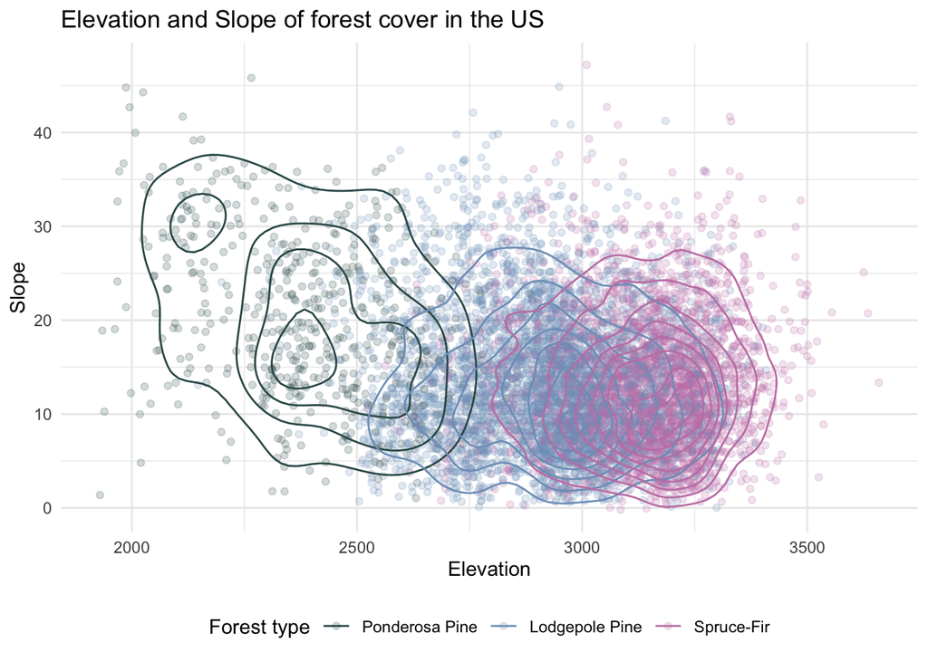

```r
cover_graph <- read_csv("cover.csv")
kereru <- get_pal("Kereru")[1:3]

cover_graph |>
  filter(Type %in% c(1, 2, 3)) |>

  ggplot(mapping = aes(
    x = Elevation,
    y = Slope,
    colour = factor(Type, levels = c(3,2,1))
    )) +
  geom_jitter(alpha = 0.2) +
  geom_density_2d() +
  scale_color_manual(values = kereru,
                     name = "Forest type",
                     labels = c("Ponderosa Pine", "Lodgepole Pine", "Spruce-Fir")) +

  labs(title = "Elevation and Slope of forest cover in the US") +
  theme_minimal() +
  theme(legend.position = "bottom")
```